# Prosper Loan Data Communication

### Carla Ferreira

## Investigation Overview

In this investigation, we are looking at the characteristics of loans and how they influence the loans. The main focus was on the APR, loan amount, prosper rating, loan term, employment and income.

## Dataset Overview

The dataset consisted of 113937 loans. These are associated with multiple variables that can describe the borrower and the loan. The dataset can be found in Udacity's repository from the module "Communicate Data Findings".

## Distribution of Borrower APR

> The distribution of APR looks multimodal. Having found small peak centered at 0.1, 0.2 and 0.3. Additionally, there is a very high peak at 0.36. Only very few loans have APR greater than 0.4.

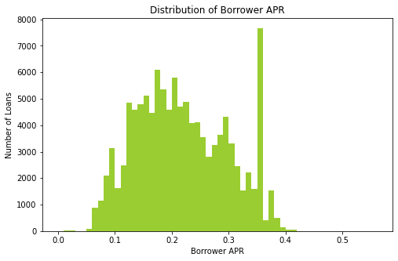

```python
bins = np.arange(0, df.BorrowerAPR.max()+0.05, 0.01)
plt.figure(figsize=[8, 5])
plt.hist(data = df, x = 'BorrowerAPR', bins = bins, color ='yellowgreen');
plt.xlabel('Borrower APR')
plt.ylabel('Number of Loans')
plt.title('Distribution of Borrower APR');
```

## Distribution of Debt to Income Ratio

> When looking at the debt to income, it appears that most borrowers who apply for a loan have a debt to income ratio around 20%. Providing us with a right skewed graph.

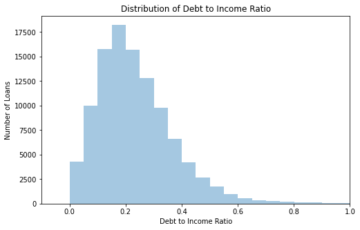

```python
# Distribution of the debt to income ratio
plt.figure(figsize = [8,5])
sb.distplot(df.DebtToIncomeRatio, kde = False, bins = 200)
plt.xlim(-.1, 1)
plt.xlabel('Debt to Income Ratio')
plt.ylabel('Number of Loans')
plt.title('Distribution of Debt to Income Ratio');
```

## Interaction between Term, rating and employment against APR, income and loan amount

> The next figure shows that the loan amount increases with the increase of the loan term. The borrower APR changes according to the rating showing a decrese with better ratings. Employed and self-employed borrowers have a higher monthly income and therefore, a higher loan amount when compared with other employment status

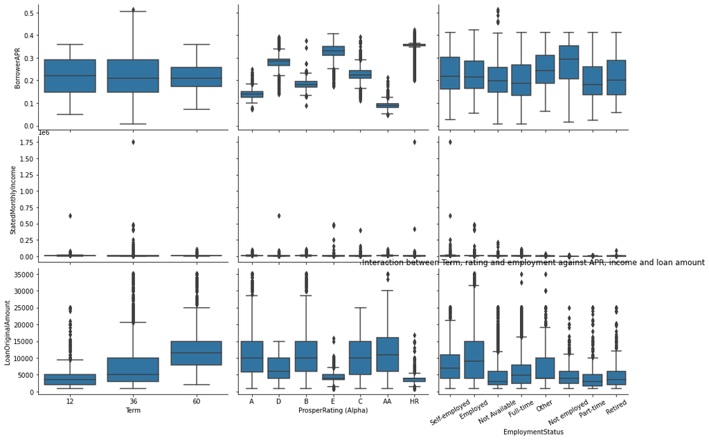

```python
# Evaluation of the numerical variables against the categorical variables
cat_vars = ['Term', 'ProsperRating (Alpha)', 'EmploymentStatus']
def boxgrid(x, y, **kwargs):

    default_color = sb.color_palette()[0]
    sb.boxplot(x, y, color = default_color)

plt.figure(figsize = [10, 10])
g = sb.PairGrid(data = df, y_vars = ['BorrowerAPR', 'StatedMonthlyIncome', 'LoanOriginalAmount'],
                x_vars = cat_vars, size = 3, aspect = 1.5)
g.map(boxgrid);
plt.xticks(rotation=30);
plt.title('Interaction between Term, rating and employment against APR, income and loan amount')
```

## Borrower APR acording to Rating and Term

> HR, E and D Ratings have higher APR. Is interesting to see how Rating A and AA have higher loan terms.

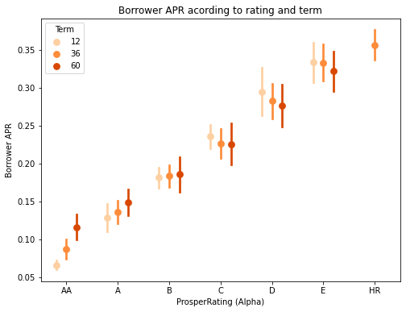

```python
ratings_order=['AA', 'A',  'B',  'C', 'D','E', 'HR']
fig = plt.figure(figsize = [8,6])
ax = sb.pointplot(data = df, x = 'ProsperRating (Alpha)', y = 'BorrowerAPR', hue = 'Term',
           palette = 'Oranges', linestyles = '', dodge = 0.4, ci='sd', order=ratings_order)
plt.title('Borrower APR acording to rating and term')
plt.ylabel('Borrower APR')
ax.set_yticklabels([],minor = True);
```

## Borrower Employment acording to APR and Term

> Not employed have higher APR and lower terms. Full time employees have a better APR and similar term frquency distribution

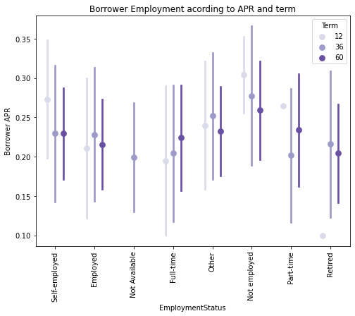

```python
fig = plt.figure(figsize = [8,6])
ax = sb.pointplot(data = df, x = 'EmploymentStatus', y = 'BorrowerAPR', hue = 'Term',
           palette = 'Purples', linestyles = '', dodge = 0.4, ci='sd')
plt.title('Borrower Employment acording to APR and term')
plt.ylabel('Borrower APR')
ax.set_yticklabels([],minor = True);
plt.xticks(rotation = 90);
```